# Comparison of the Computational Costs of Various Sampling and Prediction Methods for Gaussian Processes with Matérn Covariance Functions

David Bolin, Vaibhav Mehandiratta, and Alexandre B. Simas

Created: 2024-05-20. Last modified: 2024-05-21.

## Introduction

This vignette contains $L_2$ and $L_\infty$ distance plots of between approximated Matérn covariance function and the true Matérn covariance function:
$$r(h) =
\frac{\sigma^2}{2^{\nu-1}\Gamma(\nu)}(\kappa h)^\nu K_\nu(\kappa
h),$$
where $\Gamma(\cdot)$ is the Gamma function and $K_\nu$ is the modified Bessel function of the second kind, $\kappa$ is connected to the range of the process, $\nu$ is the smoothness parameter and $\sigma$ is the marginal standard deviation. We will consider some approximations, the reference approximation is the one based on the method introduced in (Bolin, Mehandiratta, and Simas, n.d.). We will compare it against a singular value decomposition method (PCA) and a nearest neighbor approach (Datta et al. 2016), a state-space model (Karvonen and Sarkkä 2016) and a Fourier-based low rank method (Rahimi and Recht 2007). We will use a calibration of the hyperparameter $m$ introduced in (Bolin, Mehandiratta, and Simas, n.d.) based on the theoretical costs obtained in Table 1 of (Bolin, Mehandiratta, and Simas, n.d.).

## Preprocessing

We start by installing the newest version of rSPDE to make sure all the functions we will are are available.

```r
devtools::install_github("davidbolin/rSPDE")
```

We will now load all the auxiliary functions:

```r
source("aux_functions/aux_functions_cov.R")
source("aux_functions/predict_methods.R")
source("aux_functions/distance_computations.R")
source("aux_functions/aux_dist.R")
```

```r
N <- c(1000)

nu_vec=seq(0.1,2.9, by = 0.1)
idx <- (nu_vec + 0.5)%%1 > 1e-10
nu_vec <- nu_vec[idx]
range =0.2
sigma = 1
samples = 10
m <- 1:6
```

## Computing $L_2$ and $L_\infty$ distances based on prediction calibration

We will now compute the distances with the help of the auxiliary functions `compute_distances_rational` (our method introduced in (Bolin, Mehandiratta, and Simas, n.d.)), `compute_distances_pca` (a PCA low rank approximation), `compute_distances_nngp` (the nearest neighbor method of (Datta et al. 2016)), `compute_distances_fourier` (the Fourier method of (Rahimi and Recht 2007)) and `compute_distances_statespace` (the state-space method of (Karvonen and Sarkkä 2016)).

```r
dist_rat <- compute_distances_rational(N=N, m.vec=m, nu.vec=nu_vec, range=range, sigma=sigma)

dist_nngp <- compute_distances_nngp(N=N, m.vec=m, nu.vec=nu_vec, range=range, sigma=sigma)

dist_pca <- compute_distances_pca(N=N, m.vec=m, nu.vec=nu_vec, range=range, sigma=sigma)

dist_fourier <- compute_distances_fourier(N=N, m.vec=m, nu.vec=nu_vec, range=range, sigma=sigma, samples=samples)

dist_ss <- compute_distances_statespace(N=N, m.vec=m, nu.vec=nu_vec, range=range, sigma=sigma)
```

## Distance plots based on prediction calibration

Now, we process these tables into a data frame suitable for plotting:

```r
df_dist <- process_dist(dist_rat, dist_nngp, dist_pca, dist_fourier, dist_ss)
```

### Nearest neighbor

Let us first compare the $L_2$ distances of the rational-based approximation versus nearest neighbor method, for $N=1000$:

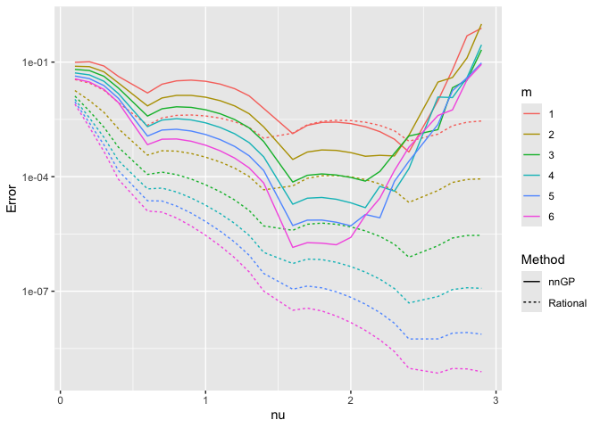

```r
plot_dist(df_dist, distance = "L2", methods = c("Rational", "nnGP"))
```

Now, the $L_\infty$ distance:

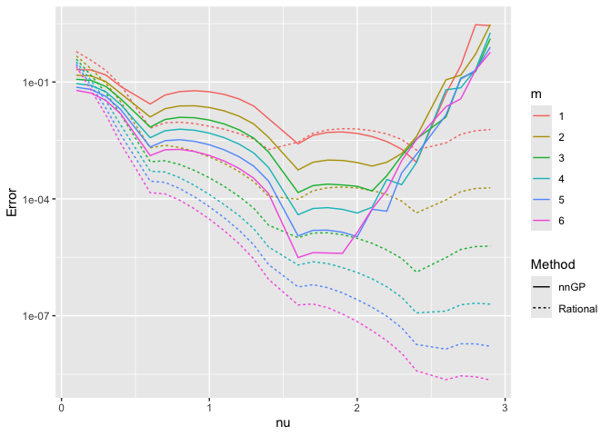

```r
plot_dist(df_dist, distance = "Linf", methods = c("Rational", "nnGP"))
```

With respect to the $L_\infty$ norm, we can see that the distances are very similar, with nnGP having a slightly better approximation for very small values of nu. For values of nu larger than 0.3, the Markov-based rational approximation outperforms the nearest neighbor approximation.

### PCA

Now, let us compare with the PCA approximation:

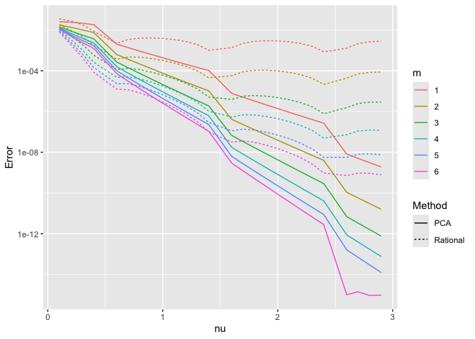

```r
plot_dist(df_dist, distance = "L2", methods = c("Rational", "PCA"))
```

We can see that the Markov-based rational approximation outperforms the PCA approximation with respect to the $L_2$ norm for values of nu less than 0.5. Also, observe that the PCA approximation is not feasible in the real world and here is working as a proxy of the best possible low rank approximation.

Now, the $L_\infty$ distance:

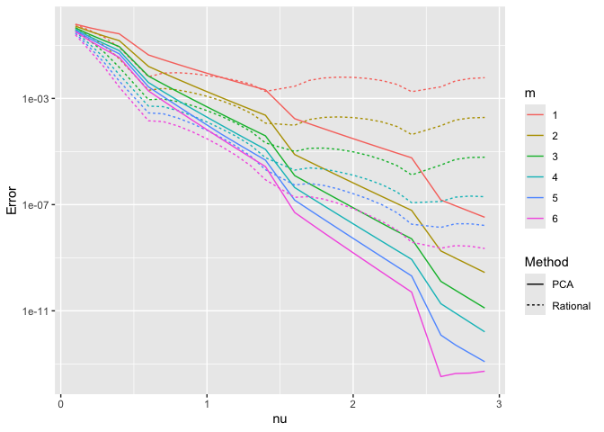

```r
plot_dist(df_dist, distance = "Linf", methods = c("Rational", "PCA"))
```

With respect to the $L_\infty$ norm, we can see that the Markov-based rational approximation outperforms the PCA approximation for nu less than 1.

### Fourier

Let us now compare with the Fourier-based approximation:

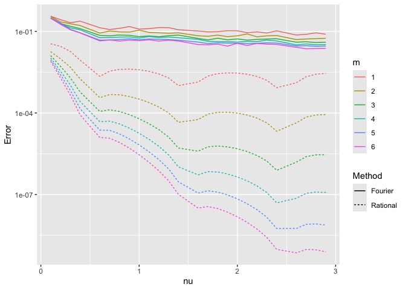

```r
plot_dist(df_dist, distance = "L2", methods = c("Rational", "Fourier"))
```

Now, the $L_\infty$ distance:

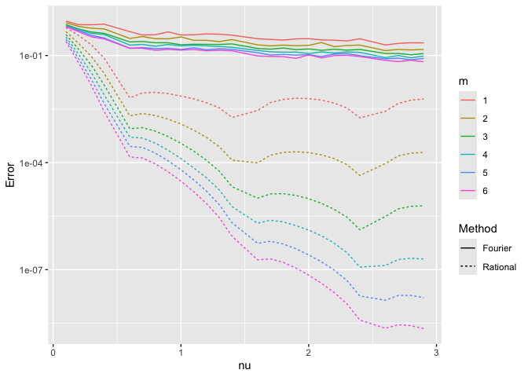

```r
plot_dist(df_dist, distance = "Linf", methods = c("Rational", "Fourier"))
```

By looking at both plots, we can see that the Fourier-based approximation is very poor compared to the other methods.

### State-space

Finally, let us compare with state-space:

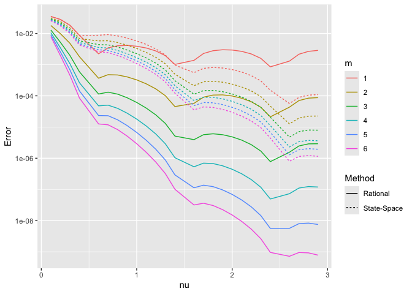

```r
plot_dist(df_dist, distance = "L2", methods = c("Rational", "State-Space"))
```

For $m\geq 2$, we have that the Markov-based rational approximation considerably outperforms the state-space approximation with respect to the $L_2$ norm. For nu greater than 2.5, the Markov-based rational approximation outperforms the state-space approximation for $m\geq 3$.

Now, the $L_\infty$ distance:

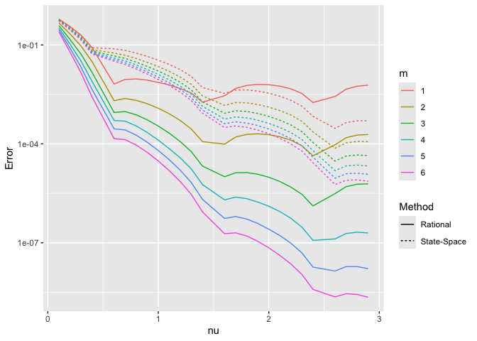

```r
plot_dist(df_dist, distance = "Linf", methods = c("Rational", "State-Space"))
```

We can see a similar behavior with respect to the $L_\infty$ norm.

## Computing $L_2$ and $L_\infty$ distances based on sampling calibration

We will now recompute all the distances by using the calibration for sampling, that is, choosing the hyperparameters so that the cost for the Markov-based rational approximation is equivalent to the computational costs of the other methods.

```r
dist_nngp_samp <- compute_distances_nngp(N=N, m.vec=m, nu.vec=nu_vec, range=range, sigma=sigma, type = "simulation")

dist_pca_samp <- compute_distances_pca(N=N, m.vec=m, nu.vec=nu_vec, range=range, sigma=sigma, type = "simulation")

dist_fourier_samp <- compute_distances_fourier(N=N, m.vec=m, nu.vec=nu_vec, range=range, sigma=sigma, samples=samples, type = "simulation")

dist_ss_samp <- compute_distances_statespace(N=N, m.vec=m, nu.vec=nu_vec, range=range, sigma=sigma, type = "simulation")
```

## Distance plots based on sampling calibration

As in the prediction case, we first process these tables into a data frame suitable for plotting:

```r
df_dist_samp <- process_dist(dist_rat, dist_nngp_samp, dist_pca_samp, dist_fourier_samp, dist_ss_samp)
```

### Nearest neighbor

Let us first compare the $L_2$ distances of the rational-based approximation versus nearest neighbor method, for $N=1000$:

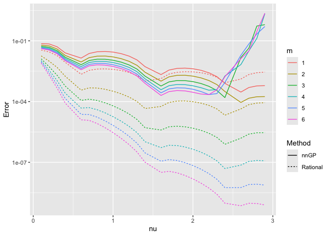

```r
plot_dist(df_dist_samp, distance = "L2", methods = c("Rational", "nnGP"))
```

Now, the $L_\infty$ distance:

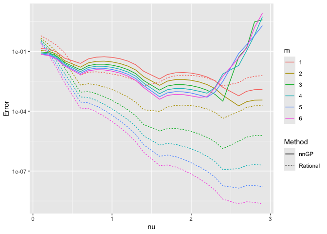

```r
plot_dist(df_dist_samp, distance = "Linf", methods = c("Rational", "nnGP"))
```

### PCA

Now, let us compare with the PCA approximation:

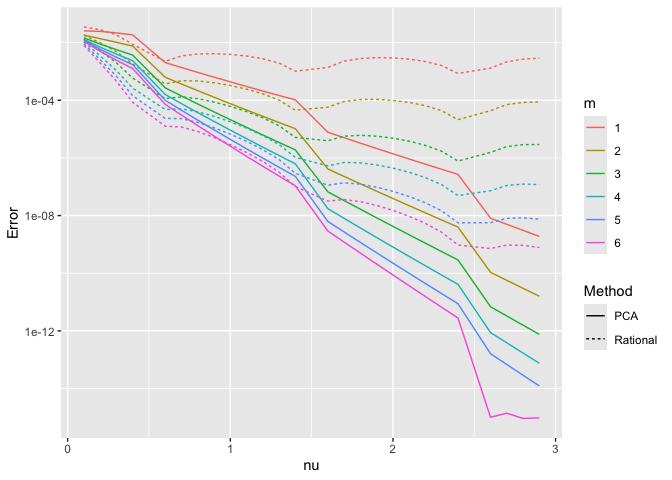

```r
plot_dist(df_dist_samp, distance = "L2", methods = c("Rational", "PCA"))
```

Now, the $L_\infty$ distance:

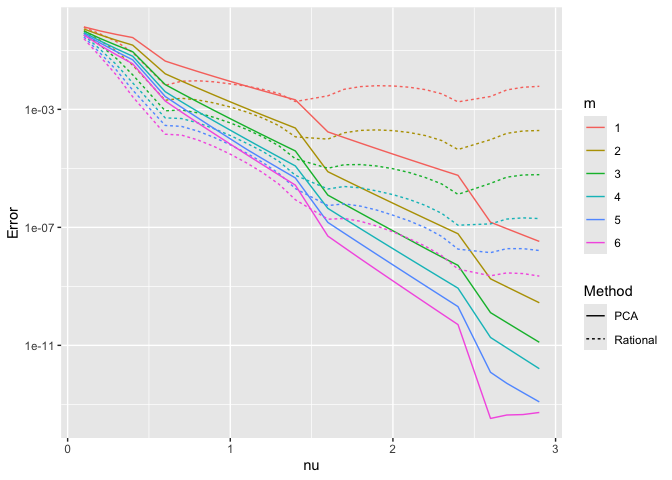

```r
plot_dist(df_dist_samp, distance = "Linf", methods = c("Rational", "PCA"))
```

### Fourier

Let us now compare with the Fourier-based approximation:

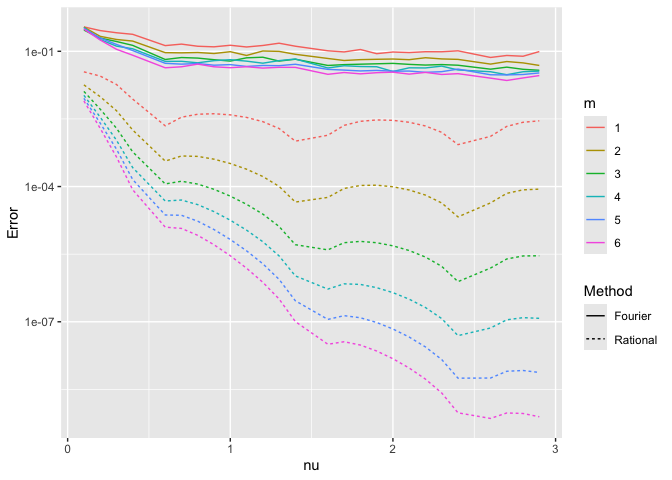

```r
plot_dist(df_dist_samp, distance = "L2", methods = c("Rational", "Fourier"))
```

Now, the $L_\infty$ distance:

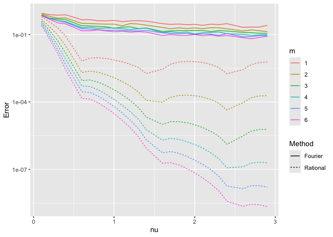

```r
plot_dist(df_dist_samp, distance = "Linf", methods = c("Rational", "Fourier"))
```

### State-space

Finally, let us compare with state-space:

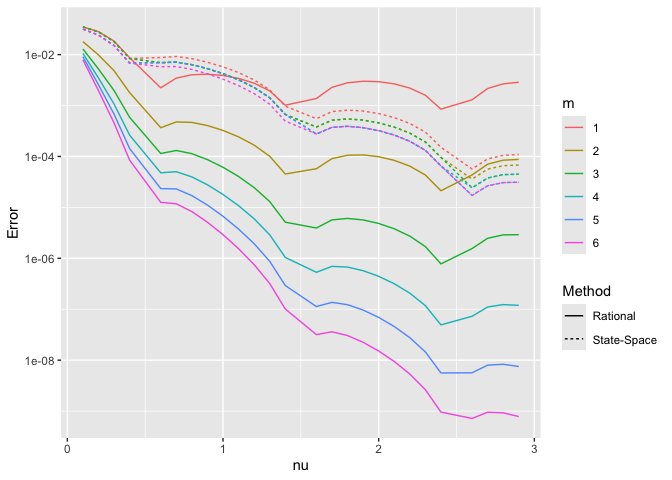

```r
plot_dist(df_dist_samp, distance = "L2", methods = c("Rational", "State-Space"))
```

Now, the $L_\infty$ distance:

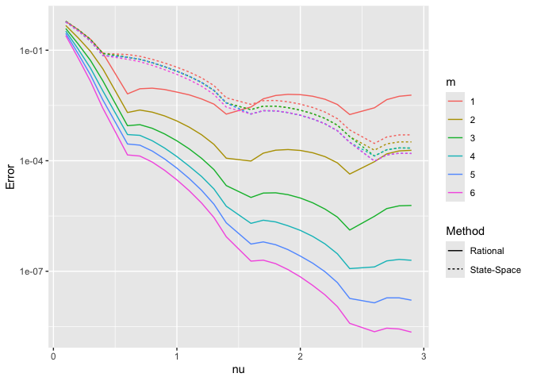

```r
plot_dist(df_dist_samp, distance = "Linf", methods = c("Rational", "State-Space"))
```

Bolin, David, Vaibhav Mehandiratta, and Alexandre B. Simas. n.d. “Linear Cost and Exponentially Convergent Approximation of Gaussian Matérn Stochastic Processes.” *Preprint*.

Datta, A., S. Benerjee, A. O. Finley, and A. E. Gelfand. 2016. “Hierarchical Nearest-Neighbor Gaussian Process Models for Large Geostatistical Datasets.” *J. Amer. Statist. Assoc.*

Karvonen, T., and S. Sarkkä. 2016. “Approximate State-Space Gaussian Processes via Spectral Transformation.” *2016 IEEE 26th International Workshop on Machine Learning for Signal Processing (MLSP)*.

Rahimi, A., and B. Recht. 2007. “Random Features for Large-Scale Kernel Machines.” *Advances in Neural Information Processing Systems*.